# Tugas Pertemuan 2 — Metode Pemulusan (Smoothing)

**Nama:** Yoan | **Mata Kuliah:** Metode Peramalan Deret Waktu (MPDW)

**Data:** Data deret waktu harian (kurs/nilai tukar), 194 observasi individu (bagian dari data kelompok ≥ 500 periode), periode 29 Oktober 2025 – 24 Agustus 2026. Data dibagi menjadi data latih (train) 80% (155 observasi) dan data uji (test) 20% (39 observasi).

## 1. Plot Data Asli

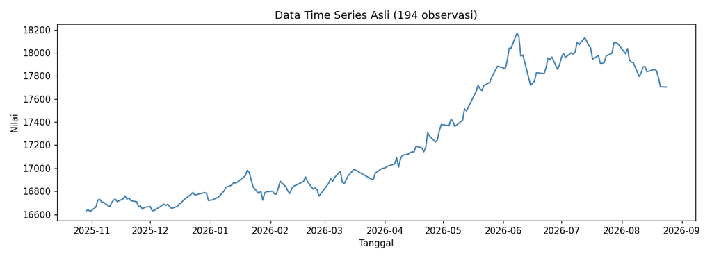

Data menunjukkan pola tren naik (upward trend) dengan fluktuasi jangka pendek, tanpa pola musiman yang jelas.

## 2. Metode Pemulusan yang Diterapkan

- **SMA(3)** dan **SMA(5)** — Simple Moving Average orde 3 dan 5
- **DMA(3)** — Double Moving Average orde 3 (untuk data bertren)
- **SES** — Single Exponential Smoothing (parameter α dioptimasi otomatis)
- **DES (Holt)** — Double Exponential Smoothing / Holt linear trend (α, β dioptimasi otomatis)
- **Holt-Winters** — Triple Exponential Smoothing aditif dengan periode musiman 5 (asumsi pola mingguan hari kerja)

## 3. Perbandingan Hasil Peramalan

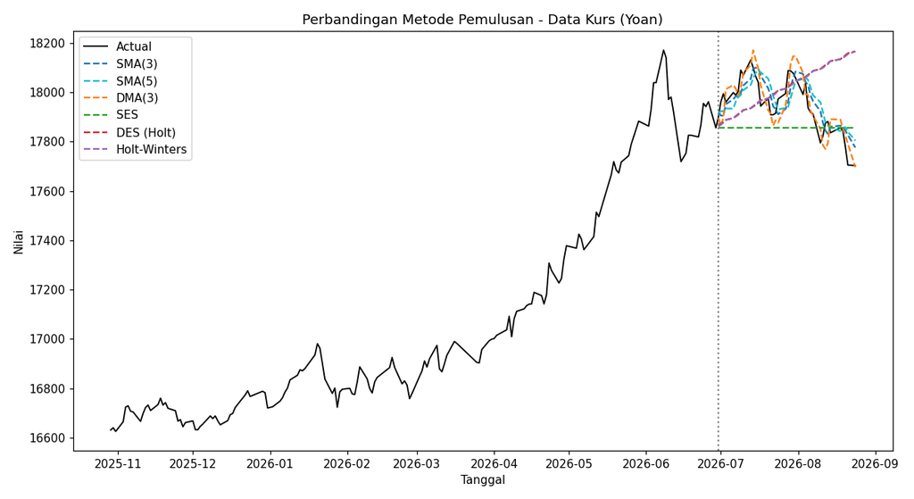

## 4. Metrik Akurasi

|  | SSE | MSE | RMSE | MAPE |
| --- | --- | --- | --- | --- |
| DMA(3) | 135,260.8889 | 3,468.2279 | 58.8917 | 0.2796 |
| SMA(3) | 158,349.7778 | 4,060.2507 | 63.7201 | 0.2950 |
| SMA(5) | 237,665.6000 | 6,093.9897 | 78.0640 | 0.3644 |
| SES | 799,890.9882 | 20,510.0253 | 143.2132 | 0.6777 |
| Holt-Winters | 1,369,723.2189 | 35,121.1082 | 187.4063 | 0.8162 |
| DES (Holt) | 1,380,548.6651 | 35,398.6837 | 188.1454 | 0.8170 |

## 5. Kesimpulan

**Metode terbaik: DMA(3) — Double Moving Average orde 3**, dengan MAPE terkecil (0,28%), diikuti oleh SMA(3) (0,29%) dan SMA(5) (0,36%).

Alasan:

- Data memiliki **tren naik yang cukup konsisten** namun tidak mengandung komponen musiman yang kuat, sehingga metode berbasis moving average yang mengakomodasi tren (DMA) lebih unggul dibanding metode level-saja (SMA murni) maupun metode eksponensial.
- SES memberikan hasil jauh lebih buruk karena hanya memuluskan level data dan tidak mampu mengikuti tren naik, sehingga peramalannya cenderung tertinggal (lag) di belakang data aktual saat tren sedang naik tajam.
- DES (Holt) dan Holt-Winters justru memberikan galat terbesar pada data ini. Ini terjadi karena parameter α teroptimasi mendekati 1 (bobot penuh pada observasi terakhir) dengan komponen tren yang diestimasi dari sedikit data awal, sehingga proyeksi tren untuk 39 periode ke depan menjadi terlalu agresif dan menyimpang jauh dari nilai aktual pada rentang uji yang cukup panjang. Model Holt-Winters juga menambahkan komponen musiman yang sebenarnya tidak relevan untuk data ini (tidak ada musiman kuat), sehingga menambah noise pada hasil peramalan.
- Metode Moving Average (khususnya DMA yang mengikuti tren secara adaptif dari rata-rata bergerak ganda) terbukti lebih stabil dan akurat untuk data dengan tren tanpa musiman ini, khususnya pada horizon peramalan yang tidak terlalu jauh.

Dibuat menggunakan Python (pandas, statsmodels, matplotlib) — Tugas Pertemuan 2, folder `Pertemuan-2`, file `Tugas-Pertemuan-2.html`.